# Visualization of Chromosomal Copy Number obtained from Whole Genome Sequencing of Fibroblasts

Daniel Piqué

March 05, 2018

## Goal

Plot distribution of CNV calls from whole genome sequencing within fibroblasts treated with different stressors.

## Project Background

The CNV calls used in this analysis come from Ginkgo ([Garvin and Schatz, Nat. Methods, 2015](https://www.ncbi.nlm.nih.gov/pmc/articles/PMC4775251/)), a recent method and web-based application that specializes in CNV calls from low-coverage DNA-sequencing in single cells. The Ginkgo output for this project is available [here](http://qb.cshl.edu/ginkgo/?q=results/IXNnDZQoQrLmexttBGP9), and the specific copy number file used in this analysis is available [here](http://qb.cshl.edu/ginkgo/uploads/IXNnDZQoQrLmexttBGP9/SegCopy?uniq=1838932). Ginkgo is appropriate as the coverage in this experiment is very low (<0.1x) and we are working with single cells.

General notes about aneuploidy (written in collaboration with Sam and Jess) are available [here](https://docs.google.com/document/d/1CJbvdZtk_0etFWD352B2qvC-dVAeRw8iNXxROs_Zp4U/edit?usp=sharing).

## Methods

```r
library(RColorBrewer)
library(tidyverse)
library(here)
library(googlesheets)
library(GenomicRanges)
library(lazyeval)

knitr::opts_knit$set(root.dir = here())
knitr::opts_chunk$set(echo=TRUE, warning=FALSE, message=FALSE)
```

1. Read in the google sheet key (link [here](https://docs.google.com/spreadsheets/d/10QTjn6EFq0yrr9XoCK62qgaiQX6i1T7dqQqtzAkhVno/edit?usp=sharing)) and additional metadata about these single cells. Metadata obtained from Elaine Maggi and from Ginkgo output (January 2018).

```r
pldyk <- gs_title("single_cell_wgs_ploidy")
pldyk2 <- gs_read(ss=pldyk, ws = "Sheet4") #283 single cells, unfiltered
pldyk3 <- pldyk2 %>%
  mutate(smpl = gsub("-", ".", file_name, fixed=T)) %>%
  separate(smpl, into = c("smpl", "toRm"), sep=".bed") %>%
  ## if the column begins with a number, add an X to the beginning of it.
  ## this is to match the column names output by Ginkgo
  mutate(smpl_1chr = if_else(is.na(as.numeric(substr(smpl, 1,1))), "", "X")) %>%
  mutate(smpl = paste0(smpl_1chr,smpl,sep="")) %>%
  select(-toRm, -smpl_1chr)

## 1/16/2018: Manually renamed T-13 to T13-3.bed (row 130 on google sheet)
## to avoid duplicates and to be consistent with the Trisomy 13 system. I
## renamed my raw bam and bed T13 files as well to T13-3 using unix.

## moved the following statements to comments
## (to avoid having these read in as separate columns)
## s33oldtube.bed - This cell was amplified with some of the samples from run2
## fish_fixed column: "Green cells were FISH fixed prior to amplification". 1 if true.

#read in ginkgo stats, copy-pasted using datapasta
source(here("scripts", "gkStats.R"))
#gkStats is a tibble with metadata from ginkgo run
```

2. Read in and munge the ginkgo count data. Summarize the data by class (12 class total), and display the counts for the unique states. Here, I use the “Integer copy-number state for each cell at every bin position; rows = bins, columns = cells”. This file is saved as “2018_01_17_ginkgo_cnv_all.txt”

```r
## Copy Number: Integer copy-number state for each cell
## at every bin position; rows = bins, columns = cells
##
## gnk is a matrix where the first 3 columns are the coordinates,
## and the rest of the columns are cells. 2 = diploid, anything other than 2
## indicates gain or loss of chromosome.
gnk <- read_tsv(here("raw_data", "2018_01_17_ginkgo_cnv_all.txt"))#, header=T)

gnk.sam <- gnk %>%
  gather(key = smpl, value=cp_nm, 4:ncol(.)) %>%
  separate(CHR, c("chrRm", "chr"), sep=3) %>%
  dplyr::select(-chrRm) %>%
  filter(chr != "Y") %>%
  mutate(chr = factor(chr, levels=c(1:22, "X"))) %>%
  left_join(pldyk3, by = "smpl") %>%
  left_join(gkStats, by = "smpl")
#write_tsv(gnk.sam, path = here("processed_data", "gnk_sam.txt"))

gnk.t <- gnk %>%
  gather(key = smpl, value=cp_nm, 4:ncol(.)) %>%
  group_by(CHR, smpl) %>%
  summarise(avg = mean(cp_nm)) %>%
  mutate(avgRound = round(avg)) %>%
  mutate(avgRound = ifelse(avgRound > 2, 1, ifelse(avgRound == 2, 0, -1))) %>%
  separate(CHR, c("chrRm", "chr"), sep=3) %>%
  dplyr::select(-chrRm) %>%
  filter(chr != "Y") %>%
  mutate(chr = factor(chr, levels=c(1:22, "X")),
         avgRound=factor(avgRound)) %>%
  left_join(pldyk3, by = "smpl") %>%
  left_join(gkStats, by = "smpl")

#now, look only at the unique states within each of the 12 classes
gnk.c <- gnk.t %>%
  mutate(clMg = paste(class, numbXtraChr_chr, sep="_")) %>%
  dplyr::select(avgRound, chr, clMg, smpl) %>%
  spread(chr, avgRound)

table(gnk.c$clMg)
```

```
##
##     Bleo treated_0_0 diabetic_patient_0_0             mock_0_0
##                   16                    1                    6
##            mock_1_13            mock_2_13      Rot treated_0_0
##                    9                    6                   15
##              sen_0_0      Tax treated_0_0       trisomy13_1_13
##                  120                   15                   14
##       trisomy18_1_18       trisomy21_1_21            young_0_0
##                   13                   13                   55
```

```r
gnk.u <- gnk.c %>%
  group_by(clMg)  %>%
  unite(colPaste, -clMg, -smpl, remove = FALSE) %>%
  count(colPaste) %>%
  mutate(prop = n / sum(n)) %>%
  separate(colPaste, c(1:22, "X"), sep = "_") %>%
  ungroup() %>%
  mutate(clMg = paste(row_number(), clMg, sep="_")) %>%
  gather(key = chr, value=chr_freq, 2:(ncol(.)-1)) %>%
  mutate(chr= factor(chr, levels=c(1:22, "X", "n"))) %>%
  mutate(clMg = factor(clMg, levels=rev(unique(clMg)[c(10:6,
              48:42, 52:49, 35:18, 5, 41:36, 17:11, 4:1)]))) %>%
  mutate(chr_freq = as.numeric(chr_freq))
```

3. Plot the summary of the chromosomal states

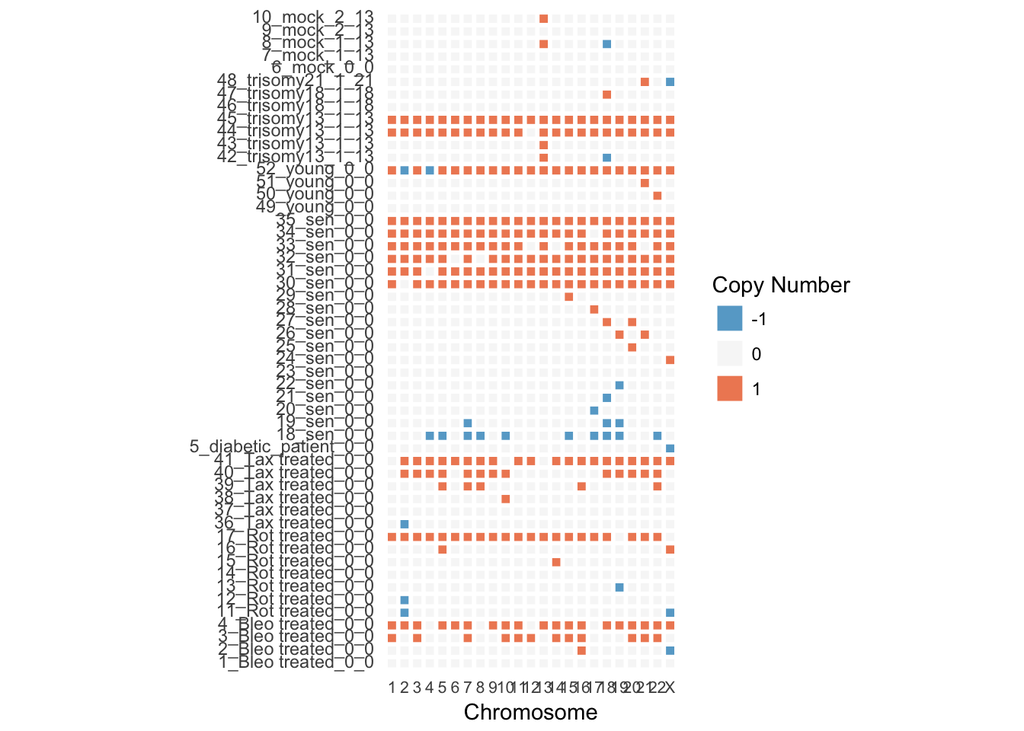

```r
ggplot(filter(gnk.u, chr %in% c(1:22,"X")), aes(x=chr, y=clMg, fill=factor(chr_freq))) + geom_tile(color = "white", size = 1) + scale_fill_brewer(type = "div",palette = "RdBu",drop=FALSE, direction = -1, name = "Copy Number") +
  theme_classic() + theme(axis.ticks = element_blank(),
                          axis.line = element_blank(),
                          axis.text.x = element_text(size= 8),
                          axis.text.y = element_text(vjust=0.3, hjust = 1)) +
  coord_fixed(ratio = 1) + xlab("Chromosome") + ylab("")
```

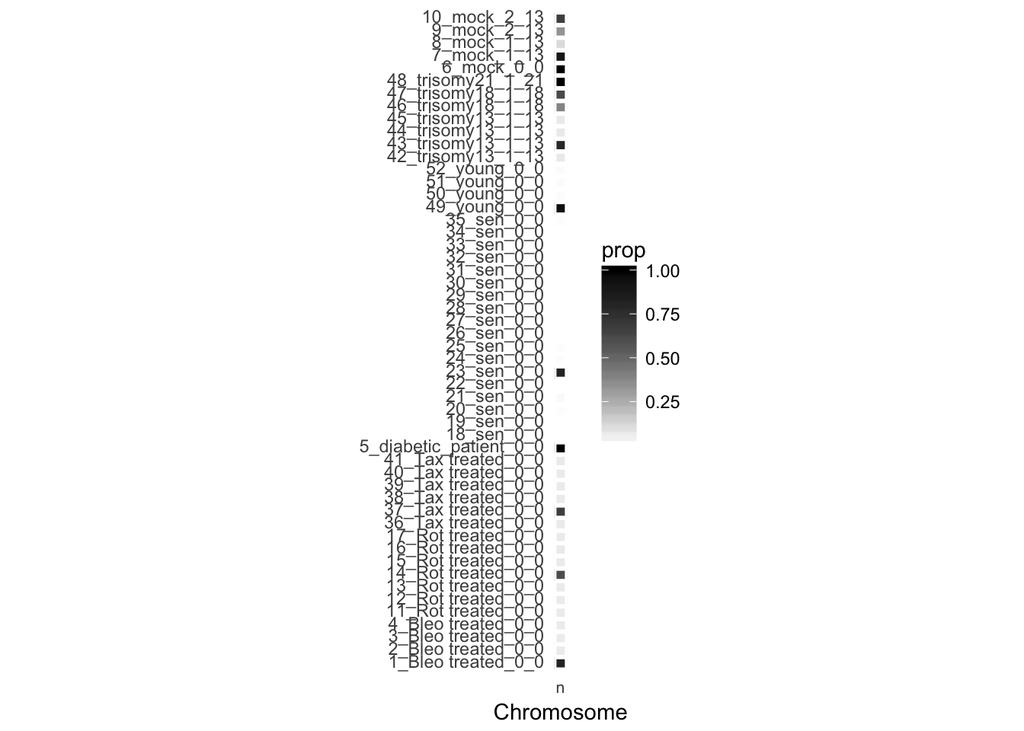

```r
ggplot(filter(gnk.u, chr == "n"), aes(x=chr, y=clMg, fill=prop)) + geom_tile(color = "white", size = 1) + scale_fill_gradient(low = "white", high = "black" ) +
  theme_classic() + theme(axis.ticks = element_blank(),
                          axis.line = element_blank(),
                          axis.text.x = element_text(size= 8),
                          axis.text.y = element_text(vjust=0.3, hjust = 1)) +
  coord_fixed(ratio = 1) + xlab("Chromosome") + ylab("")
```